# Red Wine Quality Exploration by Yanrong Mu

> **Introduction**: This report explores a dataset containing 1,599 red wines with 11 variables on the chemical properties of the wine and the quality of each wine, providing a rating between 0 (very bad) and 10 (very excellent).

# Univariate Plots Section

```
## [1] 1599   13
```

```
##  [1] "X"                    "fixed.acidity"        "volatile.acidity"
##  [4] "citric.acid"          "residual.sugar"       "chlorides"
##  [7] "free.sulfur.dioxide"  "total.sulfur.dioxide" "density"
## [10] "pH"                   "sulphates"            "alcohol"
## [13] "quality"
```

```
## 'data.frame':    1599 obs. of  13 variables:
##  $ X                   : int  1 2 3 4 5 6 7 8 9 10 ...
##  $ fixed.acidity       : num  7.4 7.8 7.8 11.2 7.4 7.4 7.9 7.3 7.8 7.5 ...
##  $ volatile.acidity    : num  0.7 0.88 0.76 0.28 0.7 0.66 0.6 0.65 0.58 0.5 ...
##  $ citric.acid         : num  0 0 0.04 0.56 0 0 0.06 0 0.02 0.36 ...
##  $ residual.sugar      : num  1.9 2.6 2.3 1.9 1.9 1.8 1.6 1.2 2 6.1 ...
##  $ chlorides           : num  0.076 0.098 0.092 0.075 0.076 0.075 0.069 0.065 0.073 0.071 ...
##  $ free.sulfur.dioxide : num  11 25 15 17 11 13 15 15 9 17 ...
##  $ total.sulfur.dioxide: num  34 67 54 60 34 40 59 21 18 102 ...
##  $ density             : num  0.998 0.997 0.997 0.998 0.998 ...
##  $ pH                  : num  3.51 3.2 3.26 3.16 3.51 3.51 3.3 3.39 3.36 3.35 ...
##  $ sulphates           : num  0.56 0.68 0.65 0.58 0.56 0.56 0.46 0.47 0.57 0.8 ...
##  $ alcohol             : num  9.4 9.8 9.8 9.8 9.4 9.4 9.4 10 9.5 10.5 ...
##  $ quality             : int  5 5 5 6 5 5 5 7 7 5 ...
```

```
##        X          fixed.acidity   volatile.acidity  citric.acid
##  Min.   :   1.0   Min.   : 4.60   Min.   :0.1200   Min.   :0.000
##  1st Qu.: 400.5   1st Qu.: 7.10   1st Qu.:0.3900   1st Qu.:0.090
##  Median : 800.0   Median : 7.90   Median :0.5200   Median :0.260
##  Mean   : 800.0   Mean   : 8.32   Mean   :0.5278   Mean   :0.271
##  3rd Qu.:1199.5   3rd Qu.: 9.20   3rd Qu.:0.6400   3rd Qu.:0.420
##  Max.   :1599.0   Max.   :15.90   Max.   :1.5800   Max.   :1.000
##  residual.sugar     chlorides       free.sulfur.dioxide
##  Min.   : 0.900   Min.   :0.01200   Min.   : 1.00
##  1st Qu.: 1.900   1st Qu.:0.07000   1st Qu.: 7.00
##  Median : 2.200   Median :0.07900   Median :14.00
##  Mean   : 2.539   Mean   :0.08747   Mean   :15.87
##  3rd Qu.: 2.600   3rd Qu.:0.09000   3rd Qu.:21.00
##  Max.   :15.500   Max.   :0.61100   Max.   :72.00
##  total.sulfur.dioxide    density             pH          sulphates
##  Min.   :  6.00       Min.   :0.9901   Min.   :2.740   Min.   :0.3300
##  1st Qu.: 22.00       1st Qu.:0.9956   1st Qu.:3.210   1st Qu.:0.5500
##  Median : 38.00       Median :0.9968   Median :3.310   Median :0.6200
##  Mean   : 46.47       Mean   :0.9967   Mean   :3.311   Mean   :0.6581
##  3rd Qu.: 62.00       3rd Qu.:0.9978   3rd Qu.:3.400   3rd Qu.:0.7300
##  Max.   :289.00       Max.   :1.0037   Max.   :4.010   Max.   :2.0000
##     alcohol         quality
##  Min.   : 8.40   Min.   :3.000
##  1st Qu.: 9.50   1st Qu.:5.000
##  Median :10.20   Median :6.000
##  Mean   :10.42   Mean   :5.636
##  3rd Qu.:11.10   3rd Qu.:6.000
##  Max.   :14.90   Max.   :8.000
```

Our dataset consists of 12 variables (variable ‘X’ can be considered as ID), with almost 1,599 observations. The structure of dataset and summary of each variable are shown above.

```
##   3   4   5   6   7   8
##  10  53 681 638 199  18
```

I add a new variable ‘quality.level’, which has same values with ‘quality’ but an ordered factor variable, which is easier to do analysis later. From the information of this dataset, we knew that the quality is scored from 0 (worst) to 10 (best). After changing the structure, we noticed from the summary of variable ‘quality.level’ that there are only scores from 3 to 8, which means no red wine is scored by 0, 1, 2, 9 and 10.

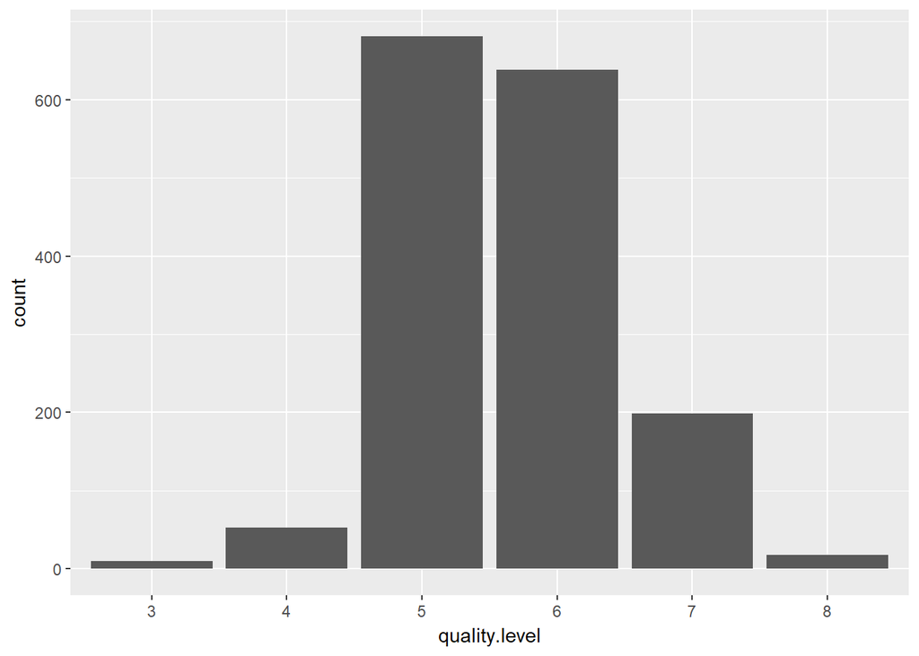

Most of red wines are of quality 5 or 6, with fewer red wines of quality 7. There are almost no red wines of quality 3 or 8, which means most red wines are of middle quality. The distribution of quality can be considered as a normal distribution.

```
##    Min. 1st Qu.  Median    Mean 3rd Qu.    Max.
##    4.60    7.10    7.90    8.32    9.20   15.90
```

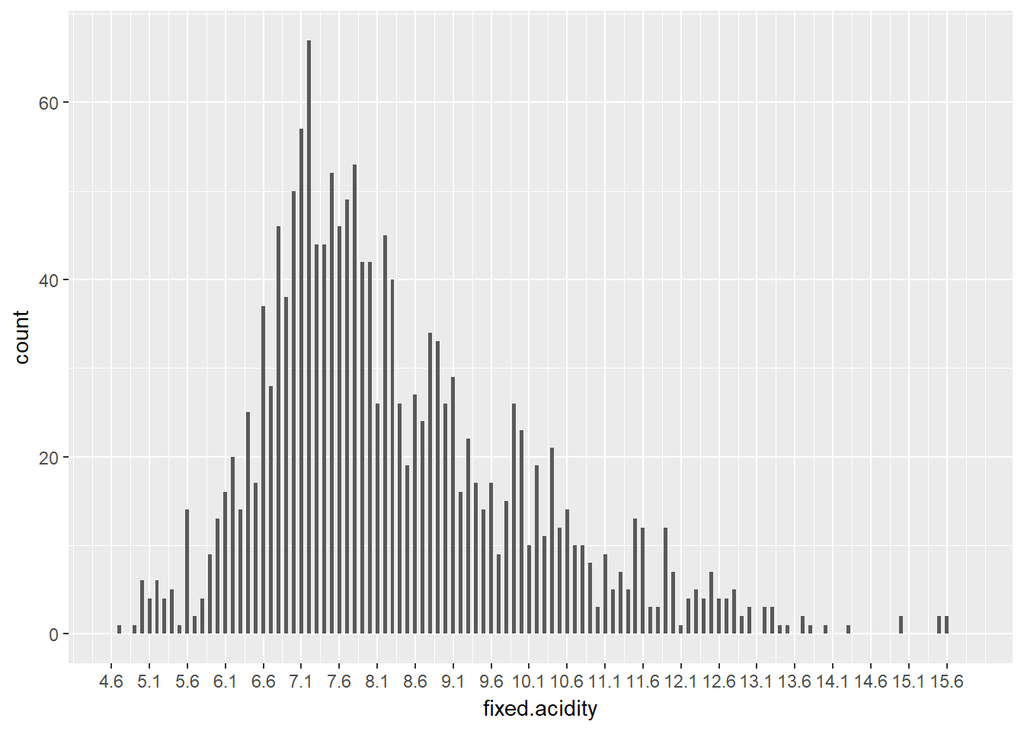

The shape of fixed acidity is a little bit skewed to the right. Most red wines have fixed acidity between 7.1 g/dm^3 and 8.1 g/dm^3: median 7.9 g/dm^3 and mean 8.32 g/dm^3.

```
##    Min. 1st Qu.  Median    Mean 3rd Qu.    Max.
##  0.1200  0.3900  0.5200  0.5278  0.6400  1.5800
```

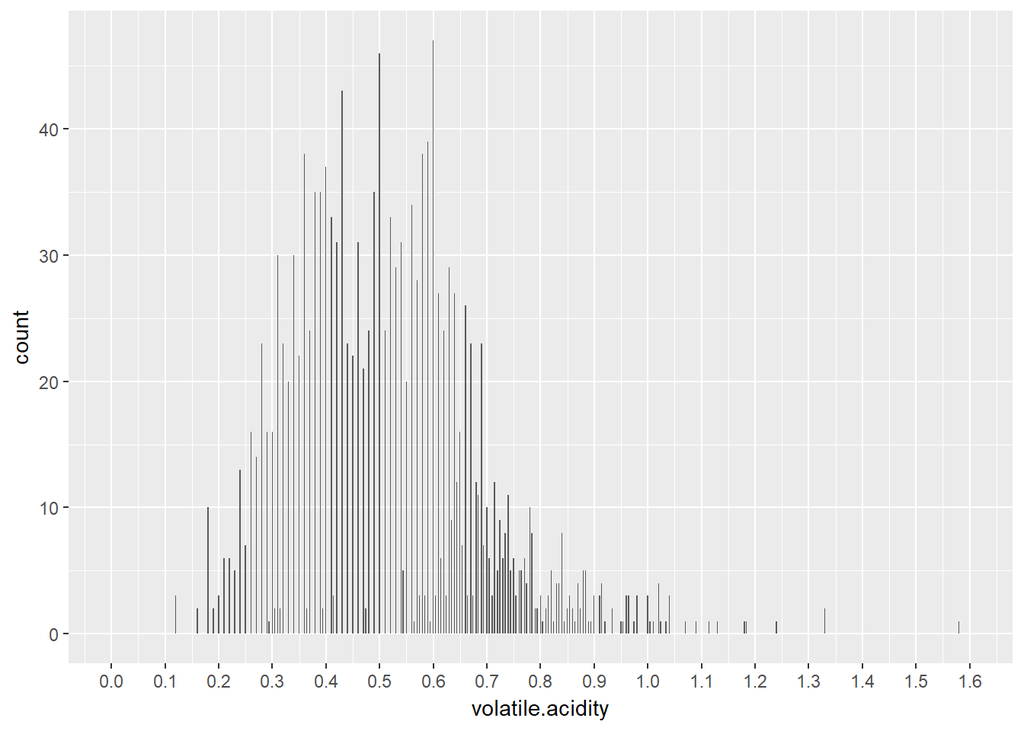

Most red wines have volatile acidity around 0.4 g/dm^3 or 0.6 g/dm^3: median 0.52 g/dm^3 and mean 0.5278 g/dm^3. There are only few red wines of high volatile acidity, maybe because too high of levels can lead to an unpleasant, vinegar taste.

```
##    Min. 1st Qu.  Median    Mean 3rd Qu.    Max.
##   0.000   0.090   0.260   0.271   0.420   1.000
```

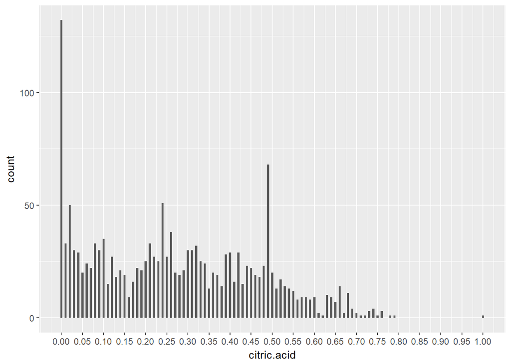

Lot of red wines do not contain citric acid, and there’s a larger amount of red wines of citric acid 0.49 g/dm^3.

```
##    Min. 1st Qu.  Median    Mean 3rd Qu.    Max.
##   0.900   1.900   2.200   2.539   2.600  15.500
```

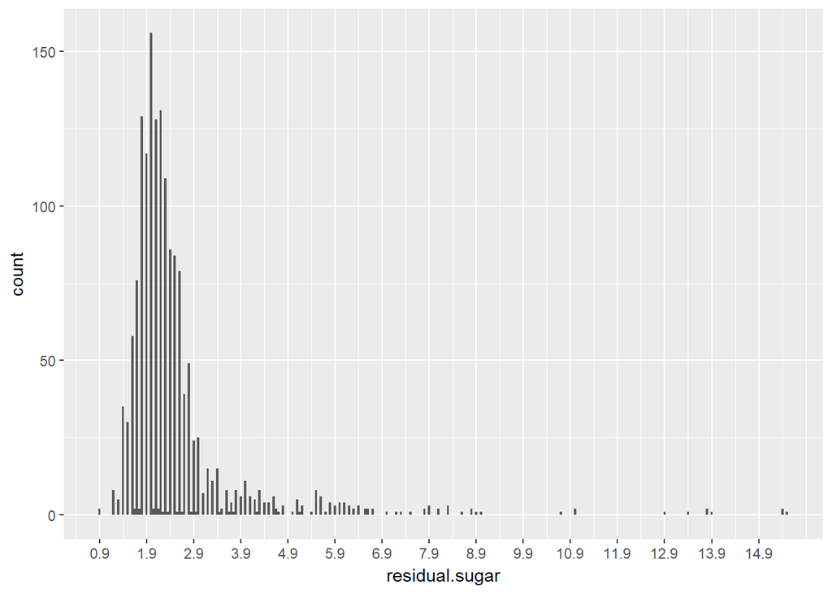

The shape of residual sugar is skewed to right, with most red wines having residual sugar between 1.6 g/dm^3 to 2.5 g/dm^3: median 2.2 g/dm^3 and mean 2.539 g/dm^3.

```
##    Min. 1st Qu.  Median    Mean 3rd Qu.    Max.
## 0.01200 0.07000 0.07900 0.08747 0.09000 0.61100
```

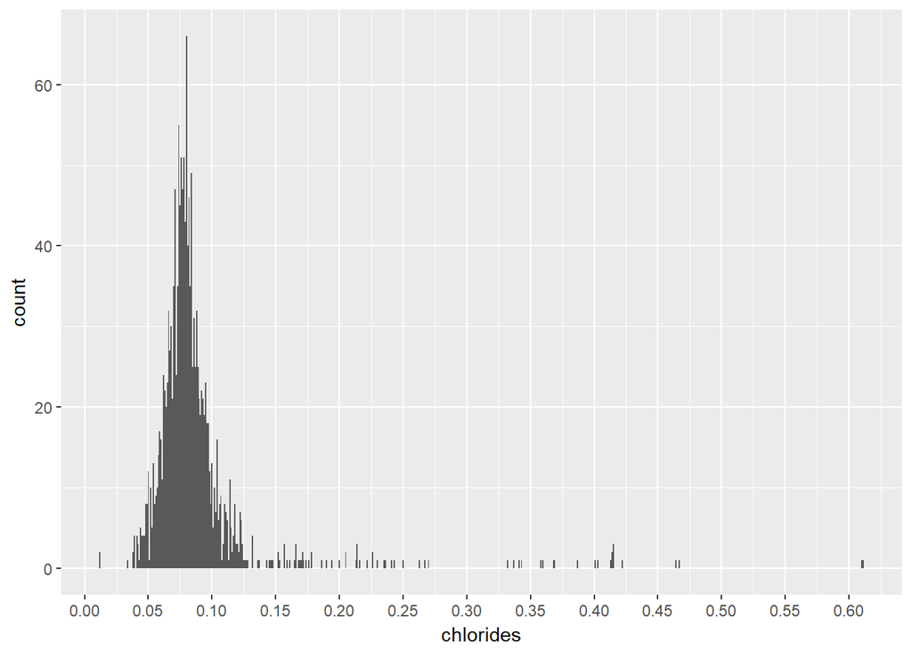

Most red wines have chlorides between 0.07 g/dm^3 and 0.09 g/dm^3: median 0.079 g/dm^3 and mean 0.08747 g/dm^3.

```
##    Min. 1st Qu.  Median    Mean 3rd Qu.    Max.
##    1.00    7.00   14.00   15.87   21.00   72.00
```

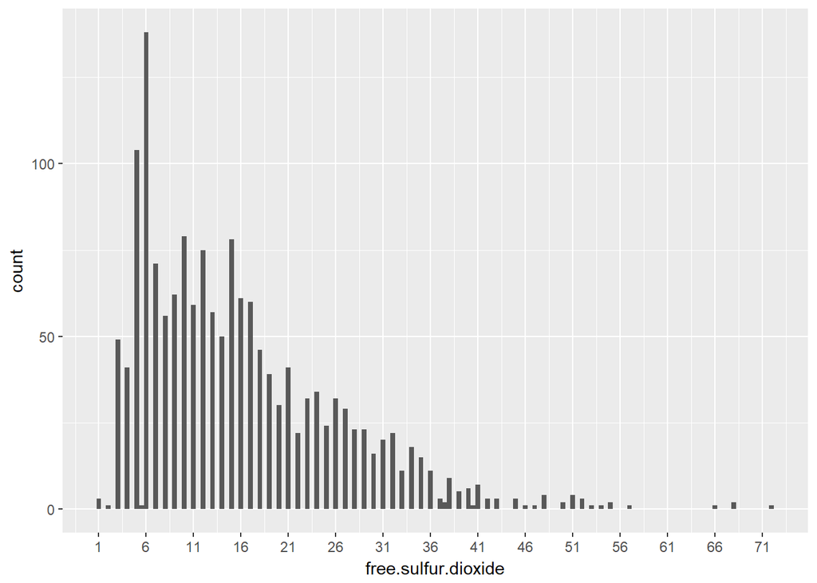

The shape of free sulfur dioxide is kind of skewed to right, with a peak at 6 mg/dm^3, and most red wines having free sulfur dioxide around 11 mg/dm^3: median 14 mg/dm^3 and mean 15.87 mg/dm^3.

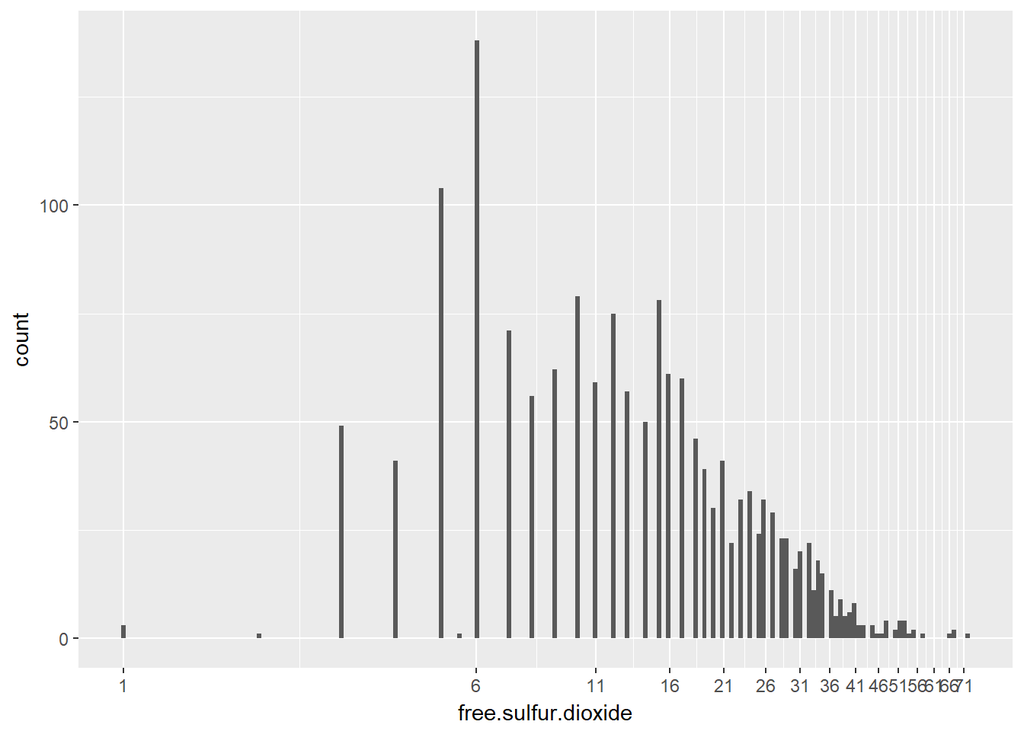

Transformed the right skewed data to better understand the distribution of free sulfur dioxide. The tranformed distribution appears kind of normal with a peak at 6 mg/dm^3, but there’s less data on left side.

```
##    Min. 1st Qu.  Median    Mean 3rd Qu.    Max.
##    6.00   22.00   38.00   46.47   62.00  289.00
```

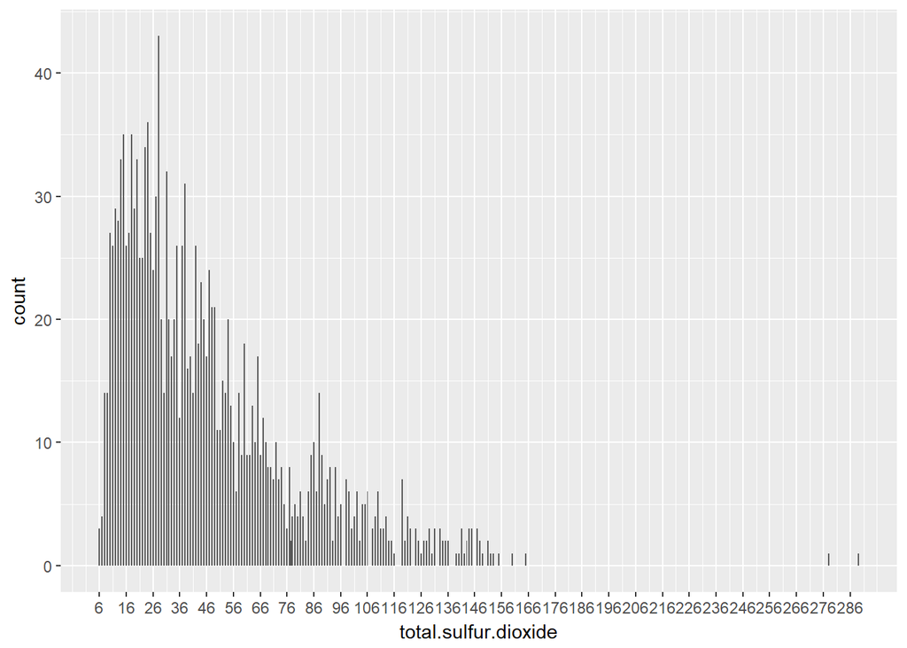

The shape of total sulfur dioxide is gradually deceasing, with a peak around 27 mg/dm^3: median 38 mg/dm^3 and mean 46.47 mg/dm^3.

```
##    Min. 1st Qu.  Median    Mean 3rd Qu.    Max.
##  0.7782  1.3424  1.5798  1.5638  1.7924  2.4609
```

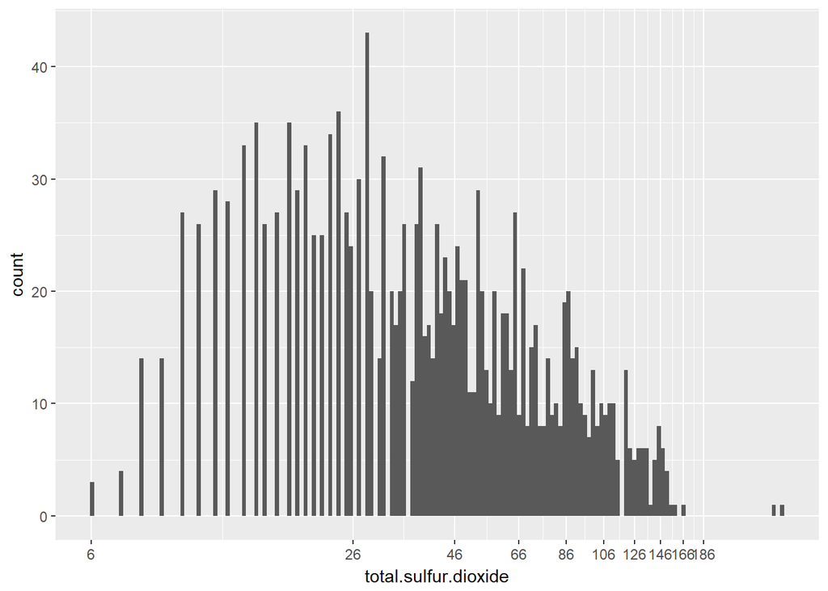

Transformed the right skewed data to better understand the distribution of total sulfur dioxide. The tranformed distribution appears normal, with a peak at 27 mg/dm^3.

```
##    Min. 1st Qu.  Median    Mean 3rd Qu.    Max.
##  0.9901  0.9956  0.9968  0.9967  0.9978  1.0037
```

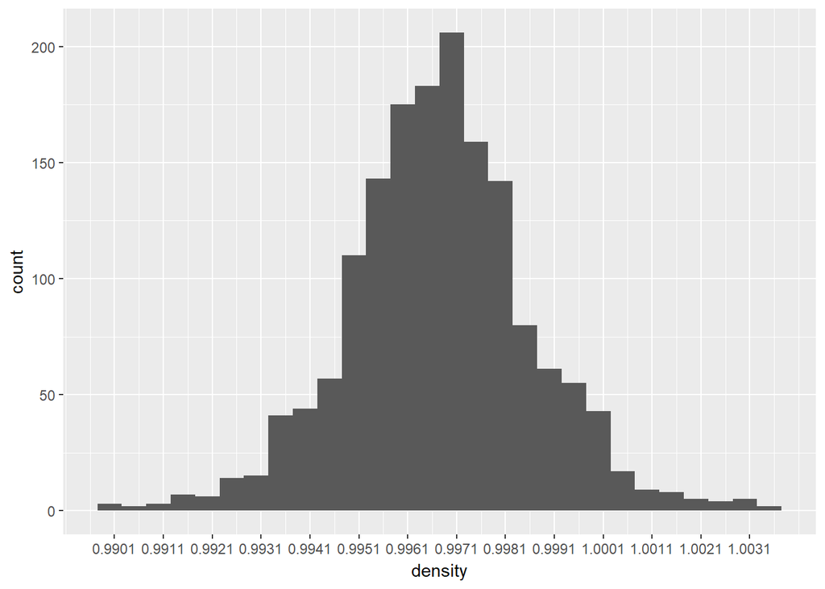

The shape of density can be considered as a normal distribution, and most red wine have density between 0.9951 g/cm^3 and 0.9981 g/cm^3: median 0.9968 g/cm^3 and mean 0.9967 g/cm^3.

```
##    Min. 1st Qu.  Median    Mean 3rd Qu.    Max.
##   2.740   3.210   3.310   3.311   3.400   4.010
```

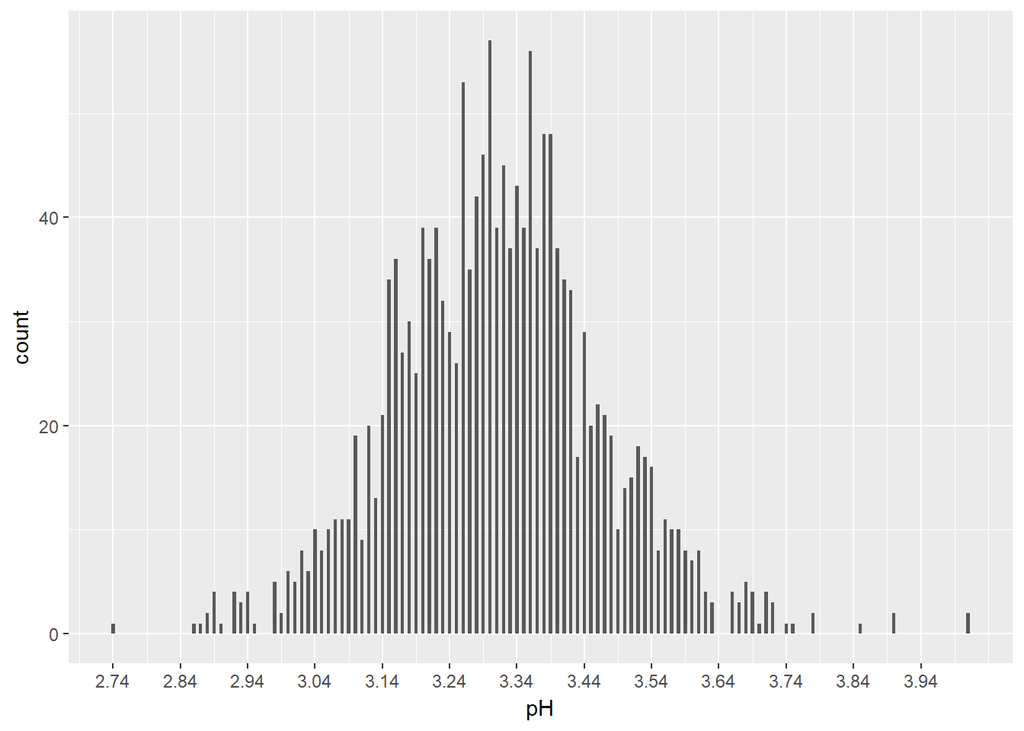

The shape of pH (0 (very acidic) to 14 (very basic)) also can be considered as a normal distribution, and most red wine have pH between 3.14 and 3.44: median 3.31 and mean 3.311.

```
##    Min. 1st Qu.  Median    Mean 3rd Qu.    Max.
##  0.3300  0.5500  0.6200  0.6581  0.7300  2.0000
```

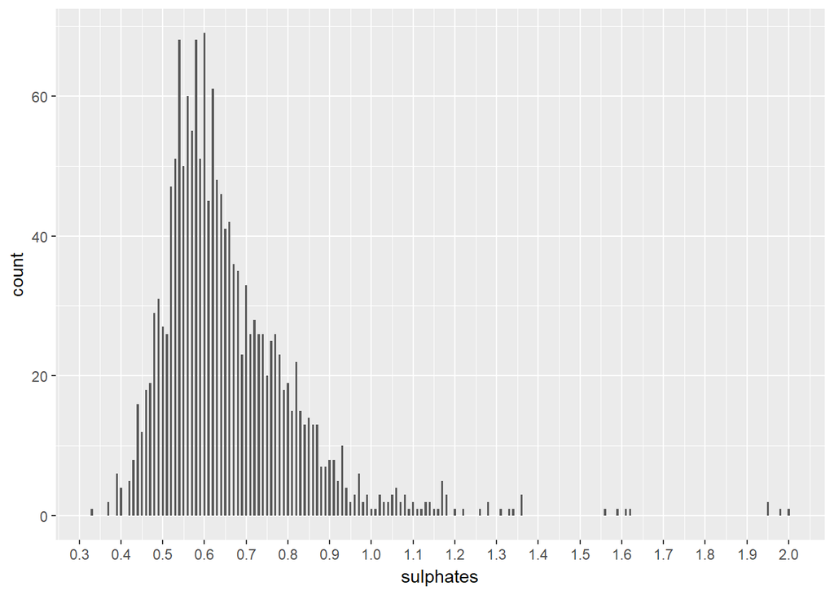

Most red wines have sulphates between 0.5 g/dm^3 and 0.7 g/dm^3: median 0.62 g/dm^3 and mean 0.6581 g/dm^3.

According to the documentation of this dataset, sulphates can contribute to sulfur dioxide gas (S02) levels. So I guess there will be some relationshape between variable sulphates and variable total.sulfur.dioxide. By comparing their own plots, it’s not easy to see the relationship, so I’ll do bivariate plot later to check their relationship.

```
##    Min. 1st Qu.  Median    Mean 3rd Qu.    Max.
##    8.40    9.50   10.20   10.42   11.10   14.90
```

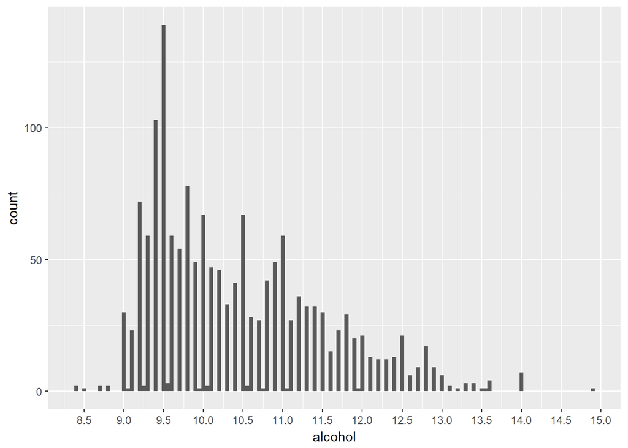

There is a peak for alcohol around 9.5% and then gradually decreasing: median 10.2% and mean 10.42%.

# Univariate Analysis

### What is the structure of your dataset?

There are 1,599 red wines in the dataset with 12 features (fixed acidity, vlatile acidity, citric acid, residual sugar, chlorides, free sulfur dioxide, total sulfur dioxide, density, PH, sulphates, alcohol, quality).

I changed variable ‘quality’ to ordered factor variabe with levels 0(worst) - 10(best). Other variables are all numbers.

### What is/are the main feature(s) of interest in your dataset?

The main features in the dataset are acidity, and quality. I’d like to determine which features are best for predicting the quality of a red wine. Only based on plots of variables, it’s hard to say which feature is more affactable on quality of red wine. I suspect some combination of the other variables can be used to build a predictive model to test the qualify of red wine.

### What other features in the dataset do you think will help support your investigation into your feature(s) of interest?

Acidity, sugar, chlorides, density, pH, sulphates and alcohol likely contribute to the quality of a red wine. I think acidity, sugar and alcohol probably contribute most to the quality after researching information on red wine. Also, I think there should be some relationship between sulphates and sulfur dioxide level.

### Did you create any new variables from existing variables in the dataset?

I create a new variable ‘quality.level’, which is changing quality to an ordered factor variable, which makes later analysis easier to follow.

### Of the features you investigated, were there any unusual distributions? Did you perform any operations on the data to tidy, adjust, or change the form of the data? If so, why did you do this?

I log-transformed the right skewed free sulfur dioxide and total sulfur dioxide distribution. The tranformed distribution for sulfur dioxide appears normal.

# Bivariate Plots Section

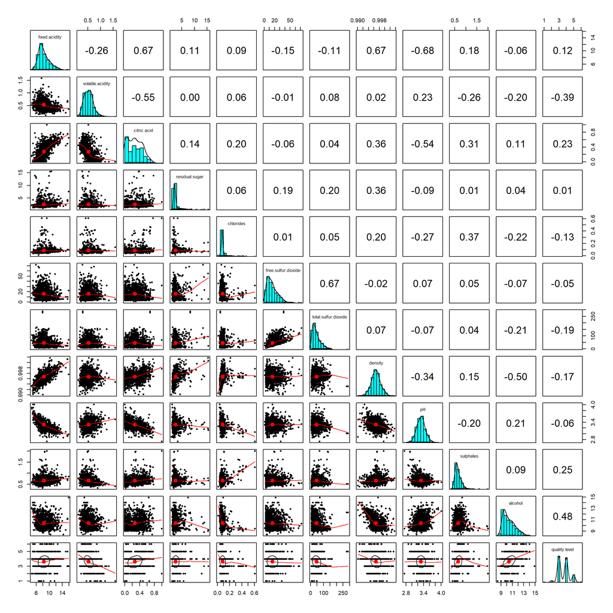

From scatterplot matrices, residual.sugur, free.sulfur.dioxide and pH do not seem to have strong correlations with quality, while volatile.acidity and alcohol have a relatively strong correlations with quality. I also want to look closer at scatter plots involving quality and some other variables like citric.acid and sulphates.

Other interesting observation between features:

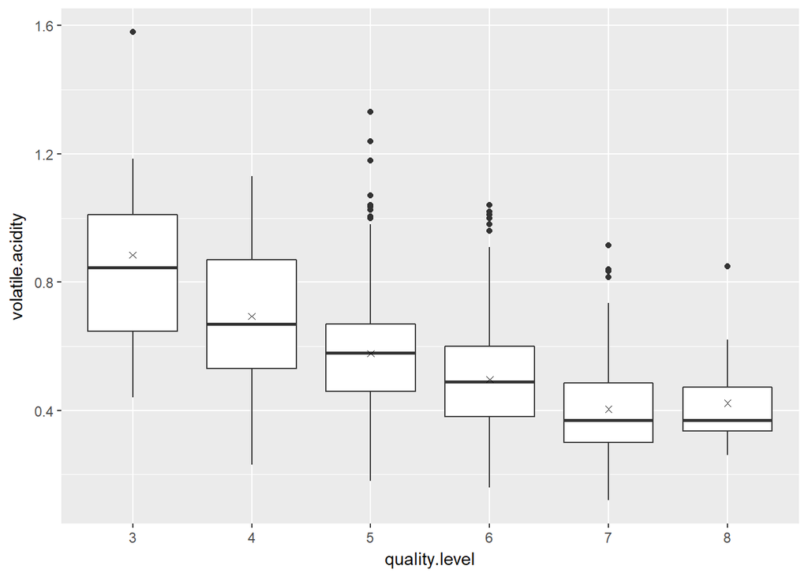

```
## wine$quality.level: 3
##    Min. 1st Qu.  Median    Mean 3rd Qu.    Max.
##  0.4400  0.6475  0.8450  0.8845  1.0100  1.5800
## --------------------------------------------------------
## wine$quality.level: 4
##    Min. 1st Qu.  Median    Mean 3rd Qu.    Max.
##   0.230   0.530   0.670   0.694   0.870   1.130
## --------------------------------------------------------
## wine$quality.level: 5
##    Min. 1st Qu.  Median    Mean 3rd Qu.    Max.
##   0.180   0.460   0.580   0.577   0.670   1.330
## --------------------------------------------------------
## wine$quality.level: 6
##    Min. 1st Qu.  Median    Mean 3rd Qu.    Max.
##  0.1600  0.3800  0.4900  0.4975  0.6000  1.0400
## --------------------------------------------------------
## wine$quality.level: 7
##    Min. 1st Qu.  Median    Mean 3rd Qu.    Max.
##  0.1200  0.3000  0.3700  0.4039  0.4850  0.9150
## --------------------------------------------------------
## wine$quality.level: 8
##    Min. 1st Qu.  Median    Mean 3rd Qu.    Max.
##  0.2600  0.3350  0.3700  0.4233  0.4725  0.8500
```

The trend looks like exactly what we assumed. Higher quality red wine has, lower volatile acid it contains. That because too high of volatile acidity levels can lead to an unpleasant, vinegar taste.

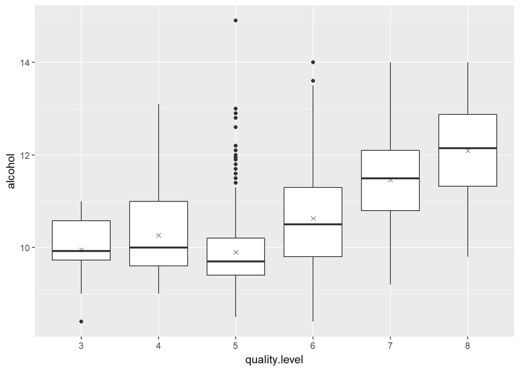

```
## wine$quality.level: 3
##    Min. 1st Qu.  Median    Mean 3rd Qu.    Max.
##   8.400   9.725   9.925   9.955  10.575  11.000
## --------------------------------------------------------
## wine$quality.level: 4
##    Min. 1st Qu.  Median    Mean 3rd Qu.    Max.
##    9.00    9.60   10.00   10.27   11.00   13.10
## --------------------------------------------------------
## wine$quality.level: 5
##    Min. 1st Qu.  Median    Mean 3rd Qu.    Max.
##     8.5     9.4     9.7     9.9    10.2    14.9
## --------------------------------------------------------
## wine$quality.level: 6
##    Min. 1st Qu.  Median    Mean 3rd Qu.    Max.
##    8.40    9.80   10.50   10.63   11.30   14.00
## --------------------------------------------------------
## wine$quality.level: 7
##    Min. 1st Qu.  Median    Mean 3rd Qu.    Max.
##    9.20   10.80   11.50   11.47   12.10   14.00
## --------------------------------------------------------
## wine$quality.level: 8
##    Min. 1st Qu.  Median    Mean 3rd Qu.    Max.
##    9.80   11.32   12.15   12.09   12.88   14.00
```

The trend seems to show that red wine with higher quality contains more alcohol. But there’s an inconsistent part at quality 5. Red wines with quality 5 seem to have a lowest alcohol percentage. Overall, the trend looks like what we thought.

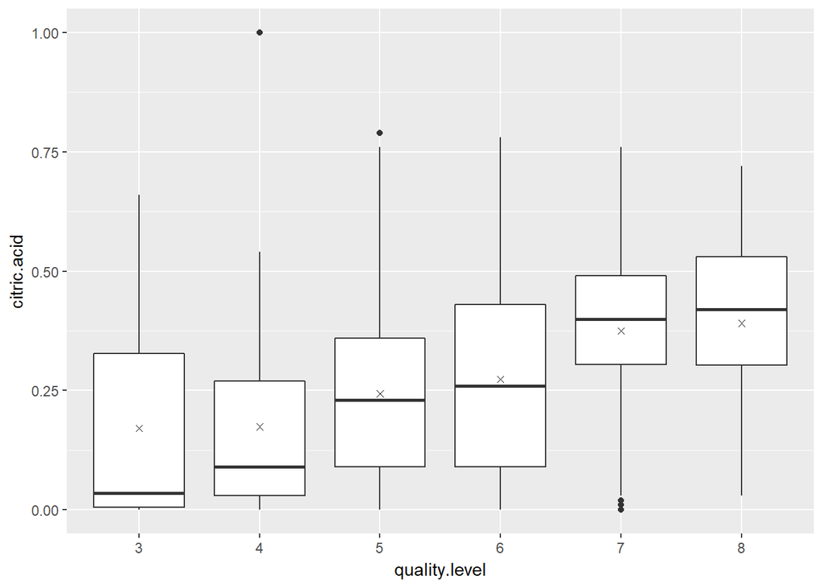

```
## wine$quality.level: 3
##    Min. 1st Qu.  Median    Mean 3rd Qu.    Max.
##  0.0000  0.0050  0.0350  0.1710  0.3275  0.6600
## --------------------------------------------------------
## wine$quality.level: 4
##    Min. 1st Qu.  Median    Mean 3rd Qu.    Max.
##  0.0000  0.0300  0.0900  0.1742  0.2700  1.0000
## --------------------------------------------------------
## wine$quality.level: 5
##    Min. 1st Qu.  Median    Mean 3rd Qu.    Max.
##  0.0000  0.0900  0.2300  0.2437  0.3600  0.7900
## --------------------------------------------------------
## wine$quality.level: 6
##    Min. 1st Qu.  Median    Mean 3rd Qu.    Max.
##  0.0000  0.0900  0.2600  0.2738  0.4300  0.7800
## --------------------------------------------------------
## wine$quality.level: 7
##    Min. 1st Qu.  Median    Mean 3rd Qu.    Max.
##  0.0000  0.3050  0.4000  0.3752  0.4900  0.7600
## --------------------------------------------------------
## wine$quality.level: 8
##    Min. 1st Qu.  Median    Mean 3rd Qu.    Max.
##  0.0300  0.3025  0.4200  0.3911  0.5300  0.7200
```

Based on median and mean points, we can conclude that better red wines has more citric acid, which is totally opposite to volatile acid.

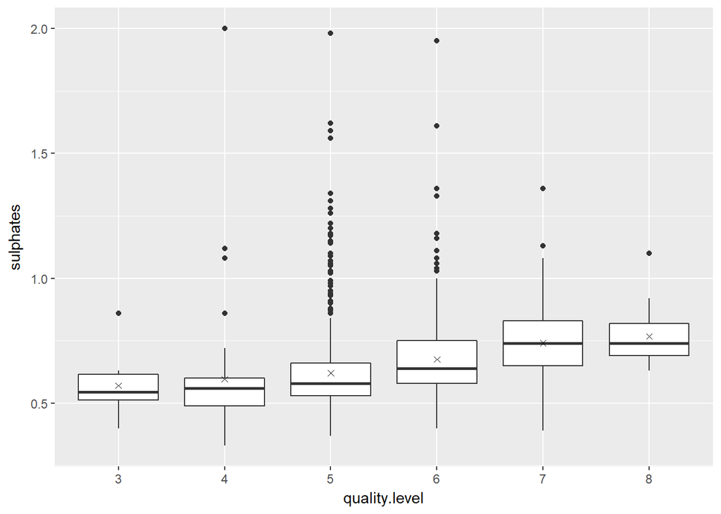

```
## wine$quality.level: 3
##    Min. 1st Qu.  Median    Mean 3rd Qu.    Max.
##  0.4000  0.5125  0.5450  0.5700  0.6150  0.8600
## --------------------------------------------------------
## wine$quality.level: 4
##    Min. 1st Qu.  Median    Mean 3rd Qu.    Max.
##  0.3300  0.4900  0.5600  0.5964  0.6000  2.0000
## --------------------------------------------------------
## wine$quality.level: 5
##    Min. 1st Qu.  Median    Mean 3rd Qu.    Max.
##   0.370   0.530   0.580   0.621   0.660   1.980
## --------------------------------------------------------
## wine$quality.level: 6
##    Min. 1st Qu.  Median    Mean 3rd Qu.    Max.
##  0.4000  0.5800  0.6400  0.6753  0.7500  1.9500
## --------------------------------------------------------
## wine$quality.level: 7
##    Min. 1st Qu.  Median    Mean 3rd Qu.    Max.
##  0.3900  0.6500  0.7400  0.7413  0.8300  1.3600
## --------------------------------------------------------
## wine$quality.level: 8
##    Min. 1st Qu.  Median    Mean 3rd Qu.    Max.
##  0.6300  0.6900  0.7400  0.7678  0.8200  1.1000
```

The trend shows that as quality becomes higher, amount of sulphates red wine contains will be slightly increasing.

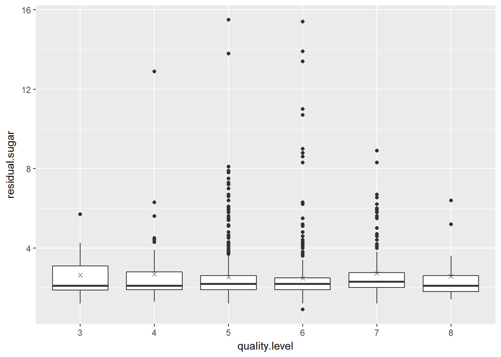

```
## wine$quality.level: 3
##    Min. 1st Qu.  Median    Mean 3rd Qu.    Max.
##   1.200   1.875   2.100   2.635   3.100   5.700
## --------------------------------------------------------
## wine$quality.level: 4
##    Min. 1st Qu.  Median    Mean 3rd Qu.    Max.
##   1.300   1.900   2.100   2.694   2.800  12.900
## --------------------------------------------------------
## wine$quality.level: 5
##    Min. 1st Qu.  Median    Mean 3rd Qu.    Max.
##   1.200   1.900   2.200   2.529   2.600  15.500
## --------------------------------------------------------
## wine$quality.level: 6
##    Min. 1st Qu.  Median    Mean 3rd Qu.    Max.
##   0.900   1.900   2.200   2.477   2.500  15.400
## --------------------------------------------------------
## wine$quality.level: 7
##    Min. 1st Qu.  Median    Mean 3rd Qu.    Max.
##   1.200   2.000   2.300   2.721   2.750   8.900
## --------------------------------------------------------
## wine$quality.level: 8
##    Min. 1st Qu.  Median    Mean 3rd Qu.    Max.
##   1.400   1.800   2.100   2.578   2.600   6.400
```

Here is a surprise, because this is a trend that goes against my intuition. I thought amount of sugar would affect the quality of red wine, but the truth seems like all levels of red wines contain pretty much the same amount of sugar remaining after fermentation stops.

Next, I’ll look closer to those interesting observations between features based on the correlation matrices.

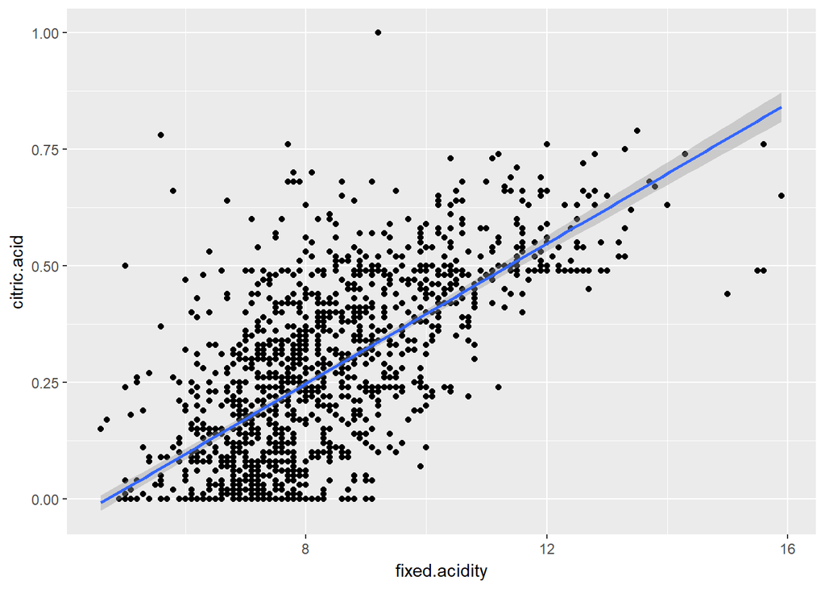

As fixed acidity increases, the overall trend of citric acidity is increasing, but we still see variance in citric acidity. There can be some linear relationship between fixed acidity and citric acidity.

```
##
## Call:
## lm(formula = citric.acid ~ fixed.acidity, data = wine)
##
## Residuals:
##      Min       1Q   Median       3Q      Max
## -0.33302 -0.11017 -0.00938  0.09317  0.71341
##
## Coefficients:
##                Estimate Std. Error t value Pr(>|t|)
## (Intercept)   -0.354270   0.017629  -20.09   <2e-16 ***
## fixed.acidity  0.075153   0.002074   36.23   <2e-16 ***
## ---
## Signif. codes:  0 '***' 0.001 '**' 0.01 '*' 0.05 '.' 0.1 ' ' 1
##
## Residual standard error: 0.1444 on 1597 degrees of freedom
## Multiple R-squared:  0.4512, Adjusted R-squared:  0.4508
## F-statistic:  1313 on 1 and 1597 DF,  p-value: < 2.2e-16
```

Based on the R^2 value of simple linear model, fixed.acidity still explains about 45 percent of the variance found in citric.acid.

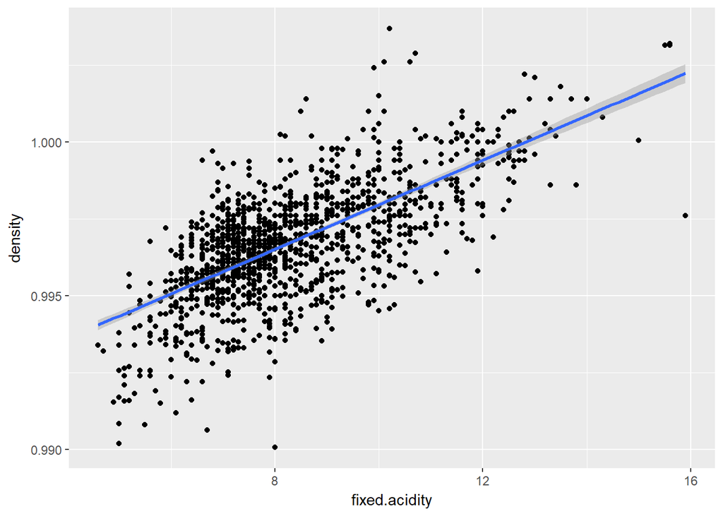

```
##
## Call:
## lm(formula = density ~ fixed.acidity, data = wine)
##
## Residuals:
##        Min         1Q     Median         3Q        Max
## -0.0064452 -0.0007700  0.0000738  0.0009434  0.0055816
##
## Coefficients:
##                Estimate Std. Error t value Pr(>|t|)
## (Intercept)   9.907e-01  1.716e-04 5774.70   <2e-16 ***
## fixed.acidity 7.242e-04  2.018e-05   35.88   <2e-16 ***
## ---
## Signif. codes:  0 '***' 0.001 '**' 0.01 '*' 0.05 '.' 0.1 ' ' 1
##
## Residual standard error: 0.001405 on 1597 degrees of freedom
## Multiple R-squared:  0.4463, Adjusted R-squared:  0.4459
## F-statistic:  1287 on 1 and 1597 DF,  p-value: < 2.2e-16
```

Based on the R^2 value of simple linear model, fixed.acidity still explains about 45 percent of the variance found in density.

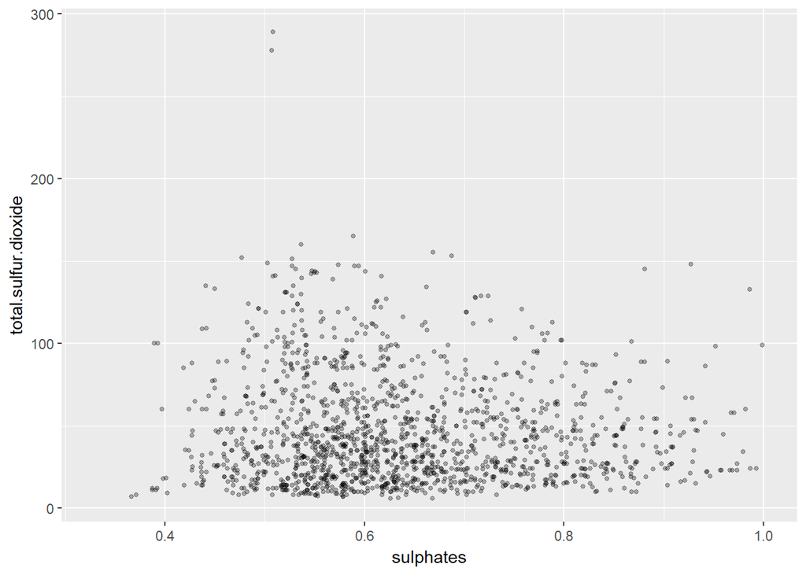

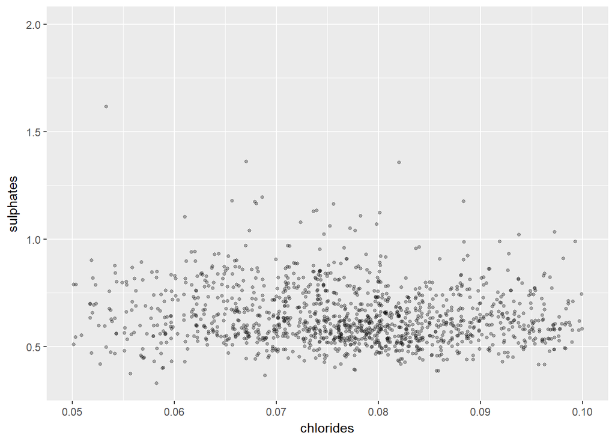

Even after adding jitter, transparency, and changing the plot limits, we still cannot see the relationship between chlorides and sulphates, which conflict with their correlation value.

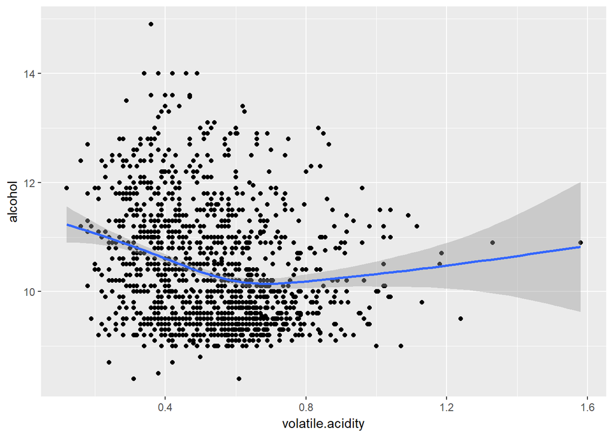

We can see that there’s no strong correlation between variables volatile.acidity and alcohol, so we could use both of these two variables to predict the quality.

# Bivariate Analysis

### Talk about some of the relationships you observed in this part of the investigation. How did the feature(s) of interest vary with other features in the dataset?

Quality correlates strongly with acidity and alcohol level.

As quality increases, the level of volatile acidity deceases, while level of citric acidity increases.

Overall, higher quality corresponding to higher level of alcohol, expect quality 5, which having a lowest average alcohol level.

Also, we can see that as quality becomes higher, amount of sulphates red wine contains will be slightly increasing.

Surprisingly, amount of sugar doesn’t have much affect to the quality.

### Did you observe any interesting relationships between the other features (not the main feature(s) of interest)?

As fixed acidity increases, the overall trend of citric acidity is increasing. Although the relationship between fixed acidity and citric acidity doesn’t look like a perfect linear relationship, based on the R^2 value, fixed.acidity still explains about 45 percent of the variance found in citric.acid.

# Multivariate Plots Section

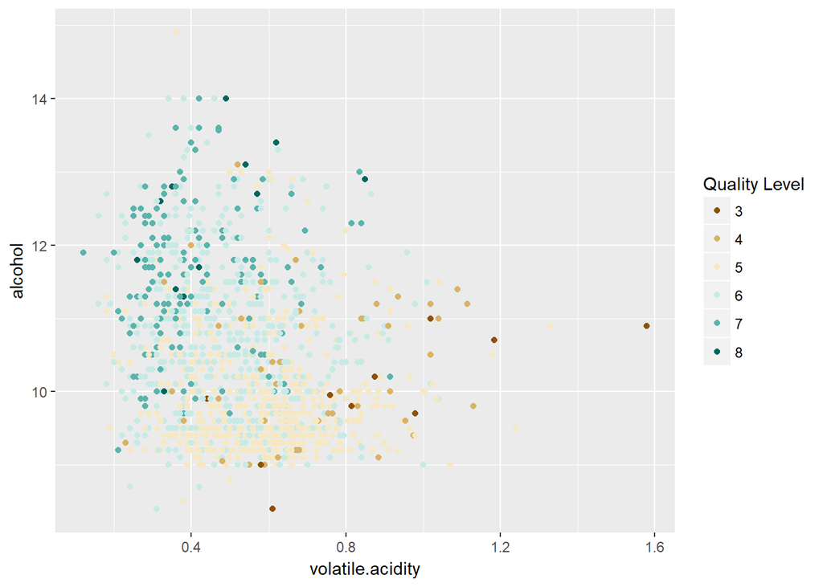

This plot seems reasonable. Points corresponding to high quality having smaller value of volatile.acidity and higher value of alcohol, which is consistent with previous observations.

# Multivariate Analysis

### OPTIONAL: Did you create any models with your dataset? Discuss the strengths and limitations of your model.

# Final Plots and Summary

# Reflection